# (PSL) Boosting

## AdaBoost

### Toy Data

The feature X is one-dimensional and uniformly generated from the interval [0, 2]. Each data point is then assigned to one of the two classes, with squares representing one class and plus signs representing the other.

```python
np.random.seed(0)
x = np.arange(1, 21)/10
n = len(x)
y = np.array([-1,-1,1,-1,-1,-1,1,-1,1,-1,1,1,-1,-1,1,1,-1,-1,-1,1])
```

### The Algorithm

The `myboosting` function is a direct implementation of one iteration of the **AdaBoost** algorithm, customized for the toy data we've generated. In this dataset, the feature X is one-dimensional and ordered in ascending order: x[1] < x[2] < ... x[n].

The weak classifier `g` is a simple random classifier. It randomly selects a sample point with an index between 1 to n-1 and predicts 1 for data points to the left of that selected point and -1 for data points to the right of the selected point. More formally, we can write `g` as follows: suppose the index of the sample point selected by g is m,

- g(x) = 1 if x < the midpoint between x[m] and x[m+1];
- g(x) = -1 if x >= the midpoint between x[m] and x[m+1];

```python
import numpy as np

def myboosting(G, w, x, y):
# G: previous committee
# w: previous weight
# x: covariates
# y: response
# g: current classifier, y=1, if x < split

 n = len(x)
 pos = np.random.choice(n-1,1) + 1
 g = np.concatenate([np.ones(pos), -np.ones(n-pos)])
 err = np.sum((1 - y*g)*w)/2
 alpha = (1/2)*np.log((1 - err)/(err))
 G = G + alpha*g
 w1 = w*np.exp(-alpha*y*g)
 w1 = w1/np.sum(w1)
 return {'G':G, 'w': w, 'w1': w1, 'g': np.sign(alpha)*g,
         'err': np.minimum(err,1-err),
         'split': (x[pos-1]+x[pos])/2, 'a': alpha}
```

The `myplot` function will be used to provide a visual illustration of AdaBoost.

```python
import matplotlib.pyplot as plt
def myplot(myout, x, y):
  n=len(x)
  m = np.sum(y>0)
  tmp1 = np.vstack([myout['w'].reshape(-1,1),myout['w1'].reshape(-1,1)]).reshape(-1,)
  tmp2 = np.vstack([(x-0.04).reshape(-1,1),x.reshape(-1,1)]).reshape(-1,)
  tmp3 = np.vstack([(5*np.ones(n)).reshape(-1,1),(6*np.ones(n)).reshape(-1,1)]).reshape(-1,)
  mymax = np.max(np.concatenate([myout['w'], myout['w1']]))

  plt.figure(figsize=(10,10))
  plt.bar(x-0.04, myout['w'], color = 'blue', width = 0.04);
  plt.bar(x, myout['w1'], color = 'green', width = 0.04);
  plt.xlim([-0.1, 2.3]);
  plt.ylim([-0.04, 0.12]);

  plt.scatter(x[y>0], np.ones(m)*(-mymax/6), marker='+', color = 'black');
  plt.scatter(x[y<0], np.ones(n-m)*(-mymax/6), marker='s', color = 'black');
  plt.scatter([np.max(x)+0.2], [-mymax/6], marker = '$1$', color = 'black', label = 'train');

  tmp1 = np.sum(myout['g']>0);
  plt.scatter(x[myout['g']>0], np.ones(tmp1)*(-mymax/3), marker='+', color = 'black');
  plt.scatter(x[myout['g']<0], np.ones(n-tmp1)*(-mymax/3), marker = 's', color = 'black');
  plt.scatter([np.max(x)+0.2], [-mymax/3], marker = '$2$', color = 'black', label = 'current');

  tmp1 = np.sum(np.sign(myout['g'][0])*np.sign(myout['g'])==1)-1
  tmp2 = np.sum((x[tmp1]+x[tmp1+1])/2)
  plt.plot(np.array([tmp2, tmp2]), np.array([-mymax/2, mymax+0.03]), linestyle = 'dashed');

  tmp1 = sum(myout['G']>0);
  plt.scatter(x[myout['G']>0], np.ones(tmp1)*(-mymax/2), marker='+', color = 'black');
  plt.scatter(x[myout['G']<0], np.ones(n-tmp1)*(-mymax/2), marker='s', color = 'black');
  plt.scatter([np.max(x)+0.2], [-mymax/2], marker = '$3$', color = 'black', label = 'overall');
  plt.legend()
```

### AdaBoost in Action

**t = 1**

```python
G = np.zeros(n)
w = np.ones(n)/n
myout = myboosting(G, w, x, y)
```

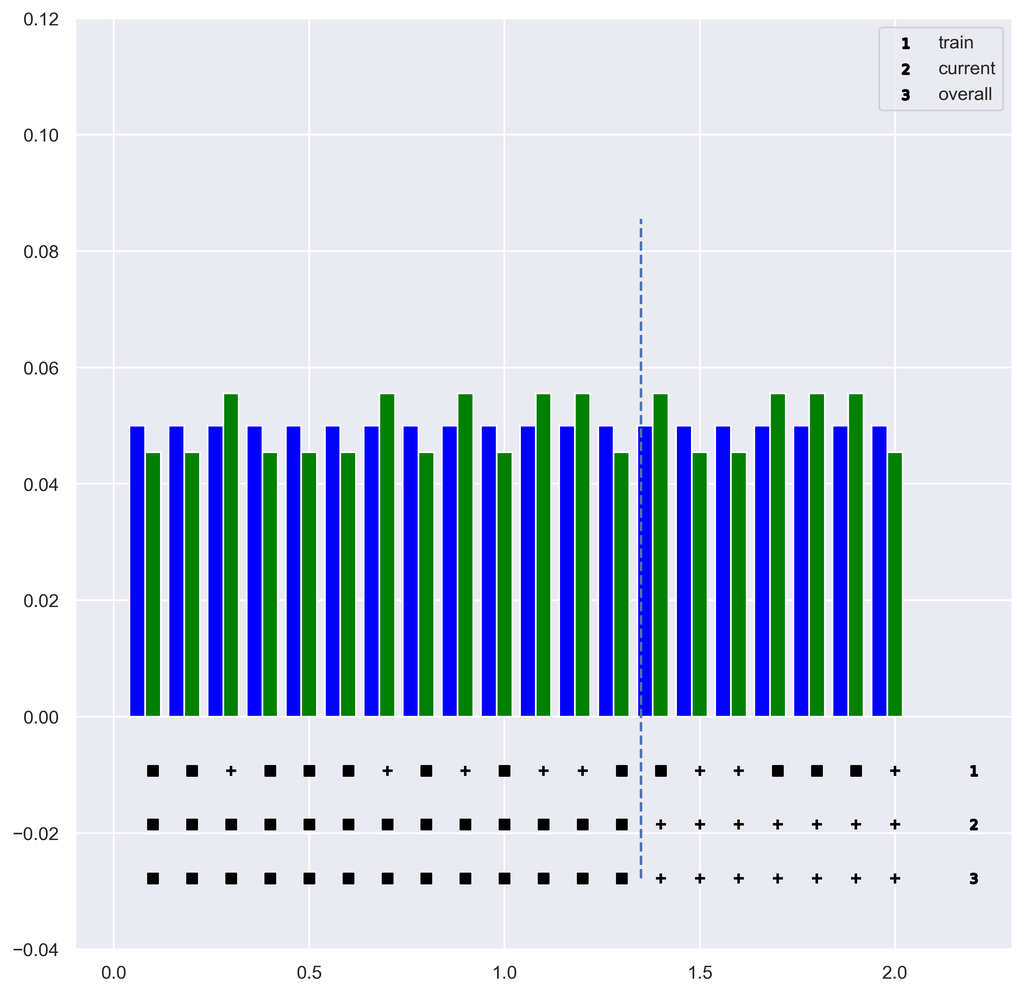

```python
import matplotlib as mpl
mpl.rcParams['figure.dpi'] = 300
myplot(myout, x, y)
```

```python
print("Error of g_t = " + str(np.around(myout['err'], 3)) +
      ", Error of G_t = " + str(np.around(np.sum(np.sign(myout['G']) != y)/n, 3)))
```

```
Error of g_t = 0.45, Error of G_t = 0.45
```

Let's discuss the visual representation after one iteration.

#### AdaBoost: t=2

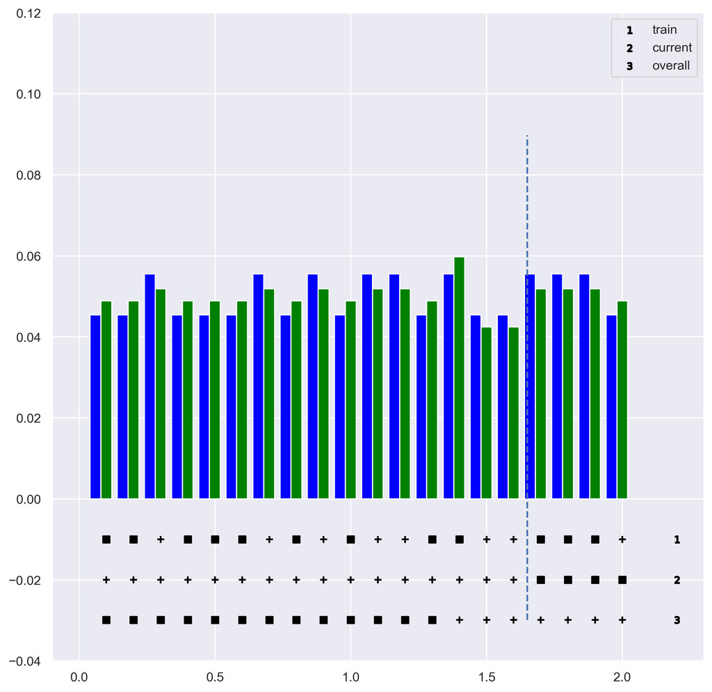

```python
myout = myboosting(myout['G'], myout['w1'], x, y)
myplot(myout, x,y)
```

```python
print("Error of g_t = " + str(np.around(myout['err'], 3)) +
      ", Error of G_t = " + str(np.around(np.sum(np.sign(myout['G']) != y)/n, 3)))
```

```
Error of g_t = 0.465, Error of G_t = 0.45
```

#### AdaBoost: t=3

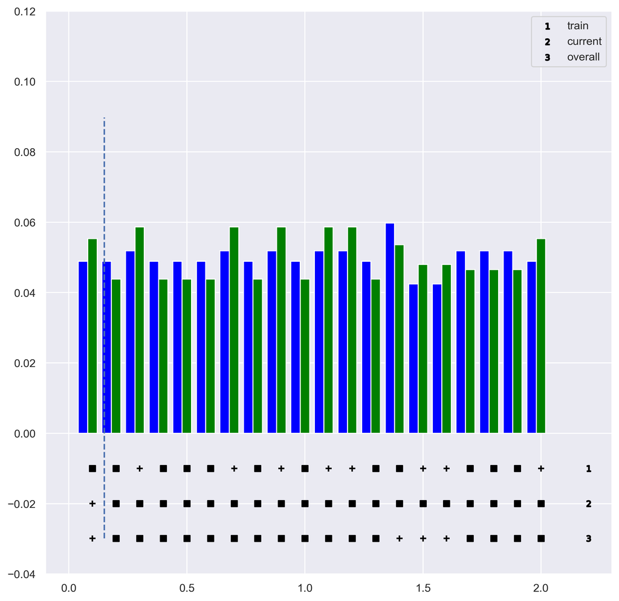

```python
myout = myboosting(myout['G'], myout['w1'], x, y)
myplot(myout, x,y)
```

```python
print("Error of g_t = " + str(np.around(myout['err'], 3)) +
      ", Error of G_t = " + str(np.around(np.sum(np.sign(myout['G']) != y)/n, 3)))
```

```
Error of g_t = 0.442, Error of G_t = 0.4
```

#### Plot the 0/1 Loss and Exponential Loss from T=200 Boosting Steps

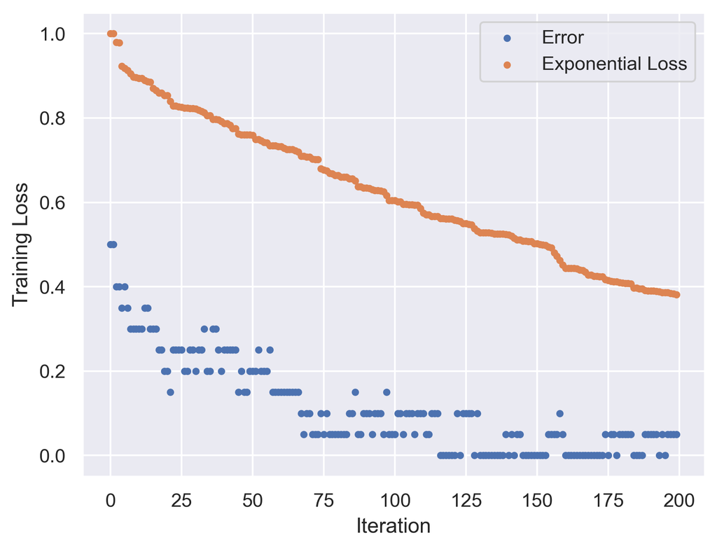

```python
T = 200
err = np.ones(T)
exploss = np.zeros(T)
n = len(x)
G = np.zeros(n)
w = np.ones(n)/n
myout = myboosting(G, w, x, y)
err[0] = np.sum(np.sign(myout['G']) != y)/n
exploss[0] = np.sum(np.exp(-y*myout['G']))/n
for i in range(1,T):
  myout = myboosting(myout['G'], myout['w1'], x, y)
  err[i] = np.sum(np.sign(myout['G']) != y)/n
  exploss[i] = np.sum(np.exp(-y*myout['G']))/n
plt.scatter(range(T), err, s = 10, label = 'Error');
plt.scatter(range(T), exploss, s = 10, label = 'Exponential Loss');
plt.legend();
plt.xlabel("Iteration");
plt.ylabel("Training Loss");
```

Here's an interesting takeaway from this illustration: the training error, represented by the blue dots, does not exhibit a consistent monotonic decrease as the number of iterations (T) increases. It's important to recall that our proof demonstrated that what decreases monotonically is not the actual training error itself but rather its upper bound, which is depicted by the orange dots.

Lastly, it's important to note that the classifier returned by AdaBoost is not guaranteed to perform well on the test data. AdaBoost tends to overfit, so it's essential to implement regularization or early stopping to achieve good generalization on test data.

## Early Stopping & Shrinkage

### Toy Data

The true density, denoted as $p(x) = P(Y=1 | X=x)$, is depicted in black on the graph. The ideal classification is shown as well, with blue representing class 0 and red representing class 1. We generated a dataset of 100 training samples from this distribution.

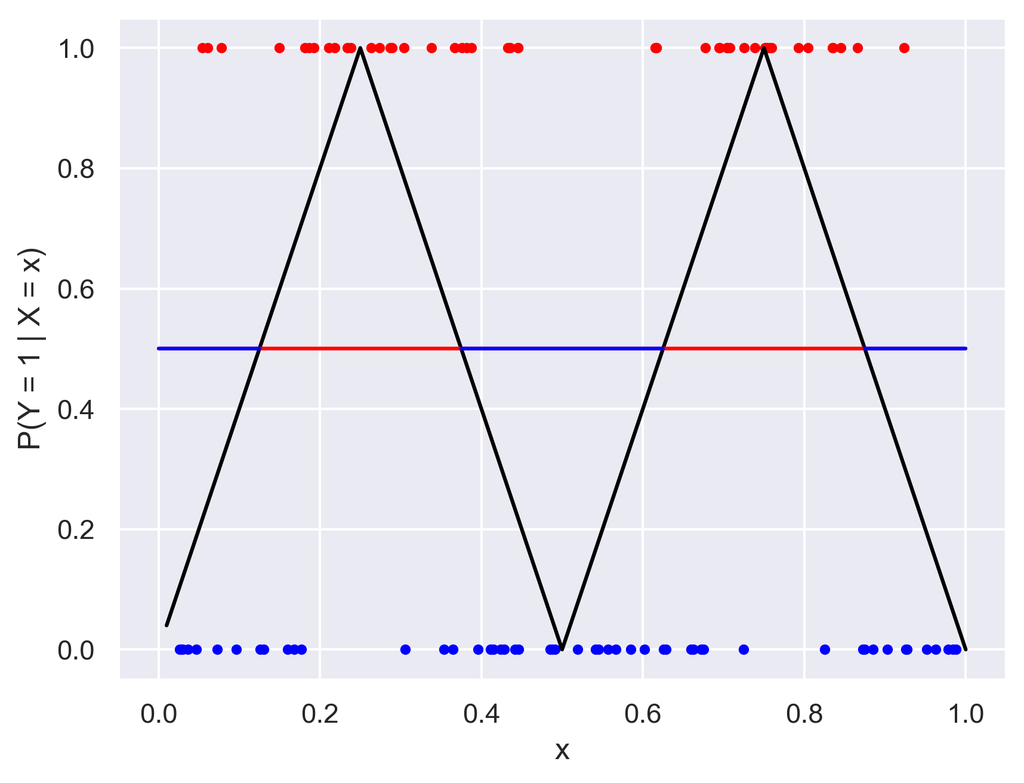

```python
d = 2
test_x = np.arange(1,101)/100
dx = d*test_x - np.floor(d*test_x)
ptest_x = 2*dx*(dx <= 0.5).astype(int) + 2*(1 - dx)*(dx > 0.5).astype(int)
plt.plot(test_x, ptest_x, color = "black");
plt.plot([0,1], [0.5,0.5], color = "red");
plt.plot([0,0.125], [0.5,0.5], color = "blue");
plt.plot([0.375, 0.625], [0.5,0.5], color = "blue");
plt.plot([0.875, 1], [0.5,0.5], color = "blue");

n = 100
x = np.sort(np.random.uniform(size = n))
dx = d*x - np.floor(d*x)
px = 2*dx*(dx <= 0.5).astype(int) + 2*(1 - dx)*(dx > 0.5).astype(int)
y = ((px - np.random.uniform(size = n)) > 0).astype(int) # y is 0/1, not -1/1
plt.scatter(x[y == 1], y[y==1], color = "red", s = 10);
plt.scatter(x[y == 0], y[y==0], color = "blue", s = 10);
plt.xlabel('x');
plt.ylabel('P(Y = 1 | X = x)');
```

### Gradient Boosting

Gradient boosting is implemented in `GradientBoostingClassifier` [[Link](https://scikit-learn.org/stable/modules/generated/sklearn.ensemble.GradientBoostingClassifier.html)].

- Available loss functions are `log_loss` (Binomial deviance) and `exponential` (same as AdaBoost)
- `n_estimators`: number of boosting iterations (i.e. number of trees)
- `learning_rate`: learning rate shrinkage factor
- `subsample`: subsample rate for base leaners

we experimented with two different sets of parameters.

- In the first case, we set shrinkage = 0.1, the default value, highlighting the importance of early stopping to obtain a better estimate of the conditional probability $P(Y=1 | X=x).$
- In the second case, we reduced the shrinkage factor to 0.001 (which necessitated an increase in the number of trees). These results demonstrate that the shrinkage factor can be helpful in reducing overfitting. The plots also indicates underfitting, so we should increase `n_estimators`.

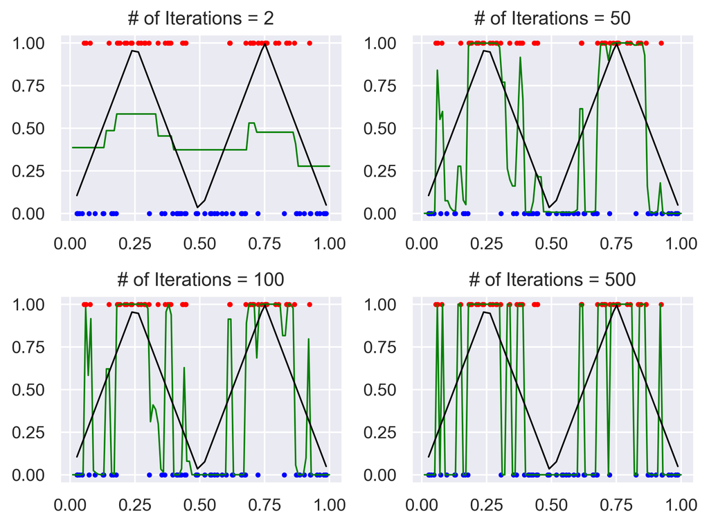

```python
from sklearn.ensemble import GradientBoostingClassifier as GBC
from scipy.special import logit
toy_gbm1 = GBC(loss = 'exponential', n_estimators = 500,
               subsample = 0.5, learning_rate = 0.1).fit(x.reshape(-1,1), y)
staged_preds = np.array([preds for preds in
                         toy_gbm1.staged_predict_proba(test_x.reshape(-1,1))])
sizes = [2, 50, 100, 500]
fig = plt.figure()
for i in range(len(sizes)):
  plt.subplot(2, 2, i+1)
  plt.scatter(x[y == 1], y[y==1], color = "red", s = 5);
  plt.scatter(x[y == 0], y[y==0], color = "blue", s = 5);
  y_pred = logit(staged_preds[sizes[i]-1,:,1])
  plt.plot(test_x, 1/(1 + np.exp(-2*y_pred)), color = 'green', linewidth = 1)
  plt.plot(x, px, color = "black", linewidth = 1)
  plt.title("# of Iterations = " + str(sizes[i]))
fig.tight_layout()
```

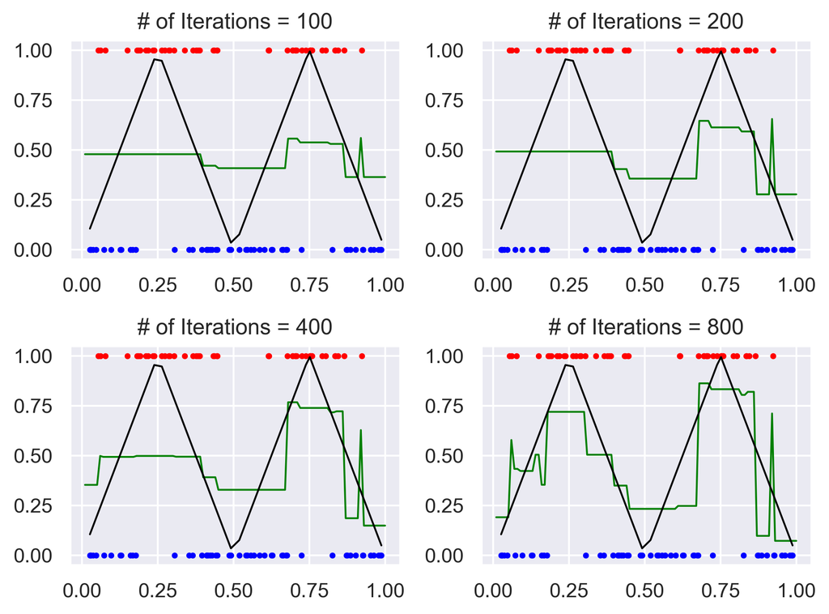

```python
toy_gbm2 = GBC(loss = 'exponential', n_estimators = 1000,
               subsample = 1, learning_rate = 0.001).fit(x.reshape(-1,1), y)
staged_preds = np.array([preds for preds in
                         toy_gbm2.staged_predict_proba(test_x.reshape(-1,1))])
sizes = [100, 200, 400, 800]
fig = plt.figure()
for i in range(len(sizes)):
  plt.subplot(2, 2, i+1)
  plt.scatter(x[y == 1], y[y==1], color = "red", s = 5);
  plt.scatter(x[y == 0], y[y==0], color = "blue", s = 5);
  y_pred = logit(staged_preds[sizes[i]-1,:,1])
  plt.plot(test_x, 1/(1 + np.exp(-2*y_pred)), color = 'green', linewidth = 1)
  plt.plot(x, px, color = "black", linewidth = 1)
  plt.title("# of Iterations = " + str(sizes[i]))
fig.tight_layout()
```